# Project: Investigate a Dataset "NoShowAppointments"

- Introduction
- Data Wrangling
- Exploratory Data Analysis
- Conclusions

## Introduction

In this project, we will analyse the dataset ["No-show appointmennts"](https://www.kaggle.com/datasets/joniarroba/noshowappointments). "This dataset collects information from 100k medical appointments in Braazil". It is about people who scheduled a doctor appointment then they showed up or not depending on several criteria that we will try to find them out. The dataset contans 14 columns with relevant data that we will try to analyze to predict if a new patient will show up or not. The dataset header is very clear and no need to clarify the columns further. The No-show category is encoded to No/Yes. We will re-encode it later to show column with 1 for No(no-NoShow==Show) and 0(yes-NoShow=Did not show up) for Yes. This will make the analysis easier rahter than analysing two negative logics. Scholarship column "indicates whether or not the patient is enrolled in The Brasilian welfare program [Bolsa Família](https://en.wikipedia.org/wiki/Bolsa_Fam%C3%ADlia)"

During this dataset analysis, we will try to answer below questions:

- Are same patients always showing up to their appointments?
- Are there some patients who have never showed up to their appointments and others who have always showed up?
- Age distribution for those who show up and who do not ((Minor-Major) or (age gap))
- Does receiving SMS impacts the arrival of patients?
- Is showing up higher with a specific gender?
- Does the duration between the scheduling day and the appointment day impacts the rate of people showing up?
- Do patients do not show up during specifc weekdays?
- Do patients do not show up during some specific days?
- Do patients enrolled in the scholarship have always showed up ?
- Does having one of the symptoms(Hypertension, Diabetes, Alcholism or a special needs person) whill restrain the patients from showing up? Which symptom is a major factor?
- Do some neighbourhood present a higher rate of people not showing up?

```python
# Use this cell to set up import statements for all of the packages that you
#   plan to use.

# Remember to include a 'magic word' so that your visualizations are plotted
#   inline with the notebook. See this page for more:
#   http://ipython.readthedocs.io/en/stable/interactive/magics.html
import numpy as np
import pandas as pd
import matplotlib.pyplot as plt
import seaborn as sns
%matplotlib inline
```

## Data Wrangling

### General Properties

```python
# Load your data and print out a few lines. Perform operations to inspect data
#   types and look for instances of missing or possibly errant data.
df = pd.read_csv('noshowappointments-kagglev2-may-2016.csv')
df.head()
```

|  | PatientId | AppointmentID | Gender | ScheduledDay | AppointmentDay | Age | Neighbourhood | Scholarship | Hipertension | Diabetes | Alcoholism | Handcap | SMS_received | No-show |
| --- | --- | --- | --- | --- | --- | --- | --- | --- | --- | --- | --- | --- | --- | --- |
| 0 | 2.987250e+13 | 5642903 | F | 2016-04-29T18:38:08Z | 2016-04-29T00:00:00Z | 62 | JARDIM DA PENHA | 0 | 1 | 0 | 0 | 0 | 0 | No |
| 1 | 5.589978e+14 | 5642503 | M | 2016-04-29T16:08:27Z | 2016-04-29T00:00:00Z | 56 | JARDIM DA PENHA | 0 | 0 | 0 | 0 | 0 | 0 | No |
| 2 | 4.262962e+12 | 5642549 | F | 2016-04-29T16:19:04Z | 2016-04-29T00:00:00Z | 62 | MATA DA PRAIA | 0 | 0 | 0 | 0 | 0 | 0 | No |
| 3 | 8.679512e+11 | 5642828 | F | 2016-04-29T17:29:31Z | 2016-04-29T00:00:00Z | 8 | PONTAL DE CAMBURI | 0 | 0 | 0 | 0 | 0 | 0 | No |
| 4 | 8.841186e+12 | 5642494 | F | 2016-04-29T16:07:23Z | 2016-04-29T00:00:00Z | 56 | JARDIM DA PENHA | 0 | 1 | 1 | 0 | 0 | 0 | No |

There is something stange in the values of ScheduledDay and AppointmentDay. The appointment is earlier then the scheduling timestamp. We will need to checkthis later.

#### check a sample of the dataset

```python
df.sample()
```

|  | PatientId | AppointmentID | Gender | ScheduledDay | AppointmentDay | Age | Neighbourhood | Scholarship | Hipertension | Diabetes | Alcoholism | Handcap | SMS_received | No-show |
| --- | --- | --- | --- | --- | --- | --- | --- | --- | --- | --- | --- | --- | --- | --- |
| 78287 | 1.836821e+13 | 5676812 | F | 2016-05-09T16:33:57Z | 2016-05-12T00:00:00Z | 28 | GRANDE VITÓRIA | 0 | 0 | 0 | 0 | 0 | 0 | No |

#### Check datset dimension

```python
print('There are',df.shape[0],'rows and', df.shape[1], 'columns')
```

```
There are 110527 rows and 14 columns
```

#### check data type in the dataset

```python
df.info()
```

```
<class 'pandas.core.frame.DataFrame'>
RangeIndex: 110527 entries, 0 to 110526
Data columns (total 14 columns):
 #   Column          Non-Null Count   Dtype
---  ------          --------------   -----
 0   PatientId       110527 non-null  float64
 1   AppointmentID   110527 non-null  int64
 2   Gender          110527 non-null  object
 3   ScheduledDay    110527 non-null  object
 4   AppointmentDay  110527 non-null  object
 5   Age             110527 non-null  int64
 6   Neighbourhood   110527 non-null  object
 7   Scholarship     110527 non-null  int64
 8   Hipertension    110527 non-null  int64
 9   Diabetes        110527 non-null  int64
 10  Alcoholism      110527 non-null  int64
 11  Handcap         110527 non-null  int64
 12  SMS_received    110527 non-null  int64
 13  No-show         110527 non-null  object
dtypes: float64(1), int64(8), object(5)
memory usage: 11.8+ MB
```

There is no missing data in this dataset.  
We will change also 'No-Show' entry to intiger by setting:  
1==The patient showed up (No)  
0==The patient did not show up (yes)

#### check general statistics of the dataset

```python
df.describe(include='all')
```

|  | PatientId | AppointmentID | Gender | ScheduledDay | AppointmentDay | Age | Neighbourhood | Scholarship | Hipertension | Diabetes | Alcoholism | Handcap | SMS_received | No-show |
| --- | --- | --- | --- | --- | --- | --- | --- | --- | --- | --- | --- | --- | --- | --- |
| count | 1.105270e+05 | 1.105270e+05 | 110527 | 110527 | 110527 | 110527.000000 | 110527 | 110527.000000 | 110527.000000 | 110527.000000 | 110527.000000 | 110527.000000 | 110527.000000 | 110527 |
| unique | NaN | NaN | 2 | 103549 | 27 | NaN | 81 | NaN | NaN | NaN | NaN | NaN | NaN | 2 |
| top | NaN | NaN | F | 2016-05-06T07:09:54Z | 2016-06-06T00:00:00Z | NaN | JARDIM CAMBURI | NaN | NaN | NaN | NaN | NaN | NaN | No |
| freq | NaN | NaN | 71840 | 24 | 4692 | NaN | 7717 | NaN | NaN | NaN | NaN | NaN | NaN | 88208 |
| mean | 1.474963e+14 | 5.675305e+06 | NaN | NaN | NaN | 37.088874 | NaN | 0.098266 | 0.197246 | 0.071865 | 0.030400 | 0.022248 | 0.321026 | NaN |
| std | 2.560949e+14 | 7.129575e+04 | NaN | NaN | NaN | 23.110205 | NaN | 0.297675 | 0.397921 | 0.258265 | 0.171686 | 0.161543 | 0.466873 | NaN |
| min | 3.921784e+04 | 5.030230e+06 | NaN | NaN | NaN | -1.000000 | NaN | 0.000000 | 0.000000 | 0.000000 | 0.000000 | 0.000000 | 0.000000 | NaN |
| 25% | 4.172614e+12 | 5.640286e+06 | NaN | NaN | NaN | 18.000000 | NaN | 0.000000 | 0.000000 | 0.000000 | 0.000000 | 0.000000 | 0.000000 | NaN |
| 50% | 3.173184e+13 | 5.680573e+06 | NaN | NaN | NaN | 37.000000 | NaN | 0.000000 | 0.000000 | 0.000000 | 0.000000 | 0.000000 | 0.000000 | NaN |
| 75% | 9.439172e+13 | 5.725524e+06 | NaN | NaN | NaN | 55.000000 | NaN | 0.000000 | 0.000000 | 0.000000 | 0.000000 | 0.000000 | 1.000000 | NaN |
| max | 9.999816e+14 | 5.790484e+06 | NaN | NaN | NaN | 115.000000 | NaN | 1.000000 | 1.000000 | 1.000000 | 1.000000 | 4.000000 | 1.000000 | NaN |

We can notice that the number of unique Appontment dates is lower in a noticable way (only 27) than the scheduling day (103549). This can explain that appointments are not always availble and they may coincide on a day when several persons cannot show up  
The minimum value of the age is -1. This value is illogic and we need to clean it later.  
The max age is 115 but we can accept this value as the oldest person in Brazil is 131 years old.  
The 'handcap' column seems to include several level of special needs.

#### check for null values

```python
df.isnull().sum()
```

```
PatientId         0
AppointmentID     0
Gender            0
ScheduledDay      0
AppointmentDay    0
Age               0
Neighbourhood     0
Scholarship       0
Hipertension      0
Diabetes          0
Alcoholism        0
Handcap           0
SMS_received      0
No-show           0
dtype: int64
```

As stated earlier, there are no missing or null objects

#### check for duplicated data

```python
df.duplicated().sum()
```

```
0
```

There are 0 duplicated data

### Data Cleaning

As discussed earlier, we will need to changee some colmuns for a better analysis experience  
We will start whith cleaning the age strange values (negative one)  
First of all, let's create a new copy of dataframe to work on it.

```python
# After discussing the structure of the data and any problems that need to be
#   cleaned, perform those cleaning steps in the second part of this section.
df2=df.copy()
df2.head()
```

|  | PatientId | AppointmentID | Gender | ScheduledDay | AppointmentDay | Age | Neighbourhood | Scholarship | Hipertension | Diabetes | Alcoholism | Handcap | SMS_received | No-show |
| --- | --- | --- | --- | --- | --- | --- | --- | --- | --- | --- | --- | --- | --- | --- |
| 0 | 2.987250e+13 | 5642903 | F | 2016-04-29T18:38:08Z | 2016-04-29T00:00:00Z | 62 | JARDIM DA PENHA | 0 | 1 | 0 | 0 | 0 | 0 | No |
| 1 | 5.589978e+14 | 5642503 | M | 2016-04-29T16:08:27Z | 2016-04-29T00:00:00Z | 56 | JARDIM DA PENHA | 0 | 0 | 0 | 0 | 0 | 0 | No |
| 2 | 4.262962e+12 | 5642549 | F | 2016-04-29T16:19:04Z | 2016-04-29T00:00:00Z | 62 | MATA DA PRAIA | 0 | 0 | 0 | 0 | 0 | 0 | No |
| 3 | 8.679512e+11 | 5642828 | F | 2016-04-29T17:29:31Z | 2016-04-29T00:00:00Z | 8 | PONTAL DE CAMBURI | 0 | 0 | 0 | 0 | 0 | 0 | No |
| 4 | 8.841186e+12 | 5642494 | F | 2016-04-29T16:07:23Z | 2016-04-29T00:00:00Z | 56 | JARDIM DA PENHA | 0 | 1 | 1 | 0 | 0 | 0 | No |

#### Clean age column

check the raws containing negative age values

```python
negativeAge=df2.query('Age<0')
negativeAge
```

|  | PatientId | AppointmentID | Gender | ScheduledDay | AppointmentDay | Age | Neighbourhood | Scholarship | Hipertension | Diabetes | Alcoholism | Handcap | SMS_received | No-show |
| --- | --- | --- | --- | --- | --- | --- | --- | --- | --- | --- | --- | --- | --- | --- |
| 99832 | 4.659432e+14 | 5775010 | F | 2016-06-06T08:58:13Z | 2016-06-06T00:00:00Z | -1 | ROMÃO | 0 | 0 | 0 | 0 | 0 | 0 | No |

There is only one entry with a negative age value. The patient did show up. So we can remove this entry as it is illogic.

```python
df2=df2.query('Age>=0')
```

```python
df2.describe()
```

|  | PatientId | AppointmentID | Age | Scholarship | Hipertension | Diabetes | Alcoholism | Handcap | SMS_received |
| --- | --- | --- | --- | --- | --- | --- | --- | --- | --- |
| count | 1.105260e+05 | 1.105260e+05 | 110526.000000 | 110526.000000 | 110526.000000 | 110526.000000 | 110526.000000 | 110526.000000 | 110526.000000 |
| mean | 1.474934e+14 | 5.675304e+06 | 37.089219 | 0.098266 | 0.197248 | 0.071865 | 0.030400 | 0.022248 | 0.321029 |
| std | 2.560943e+14 | 7.129544e+04 | 23.110026 | 0.297676 | 0.397923 | 0.258266 | 0.171686 | 0.161543 | 0.466874 |
| min | 3.921784e+04 | 5.030230e+06 | 0.000000 | 0.000000 | 0.000000 | 0.000000 | 0.000000 | 0.000000 | 0.000000 |
| 25% | 4.172536e+12 | 5.640285e+06 | 18.000000 | 0.000000 | 0.000000 | 0.000000 | 0.000000 | 0.000000 | 0.000000 |
| 50% | 3.173184e+13 | 5.680572e+06 | 37.000000 | 0.000000 | 0.000000 | 0.000000 | 0.000000 | 0.000000 | 0.000000 |
| 75% | 9.438963e+13 | 5.725523e+06 | 55.000000 | 0.000000 | 0.000000 | 0.000000 | 0.000000 | 0.000000 | 1.000000 |
| max | 9.999816e+14 | 5.790484e+06 | 115.000000 | 1.000000 | 1.000000 | 1.000000 | 1.000000 | 4.000000 | 1.000000 |

```python
df2.shape
```

```
(110526, 14)
```

##### Change ScheduledDay and AppointmentDay to datetime type and check the rate of ScheduledDay after AppointmentDay

```python
df2.ScheduledDay=pd.to_datetime(df2.ScheduledDay)
```

```python
df2.AppointmentDay=pd.to_datetime(df2.AppointmentDay)
```

```python
df2.info()
```

```
<class 'pandas.core.frame.DataFrame'>
Int64Index: 110526 entries, 0 to 110526
Data columns (total 14 columns):
 #   Column          Non-Null Count   Dtype
---  ------          --------------   -----
 0   PatientId       110526 non-null  float64
 1   AppointmentID   110526 non-null  int64
 2   Gender          110526 non-null  object
 3   ScheduledDay    110526 non-null  datetime64[ns, UTC]
 4   AppointmentDay  110526 non-null  datetime64[ns, UTC]
 5   Age             110526 non-null  int64
 6   Neighbourhood   110526 non-null  object
 7   Scholarship     110526 non-null  int64
 8   Hipertension    110526 non-null  int64
 9   Diabetes        110526 non-null  int64
 10  Alcoholism      110526 non-null  int64
 11  Handcap         110526 non-null  int64
 12  SMS_received    110526 non-null  int64
 13  No-show         110526 non-null  object
dtypes: datetime64[ns, UTC](2), float64(1), int64(8), object(3)
memory usage: 12.6+ MB
```

Check the illogic entries in the data where Wait time is negative (df2.AppointmentDay<df2.ScheduledDay)

```python
negativeWaitTime=df2.AppointmentDay<df2.ScheduledDay
```

To get the exact percentage of negative wait and positive wait in the dataset, let's draw a pie chat. As we may need to draw several pie charts later, we will create first of all a function for pie chart.

```python
def pieChart(title,entry,labelsList,figsize):
    entry.plot(kind='pie',autopct='%1.1f%%', labels=labelsList,figsize=figsize)
    plt.title(title)
    plt.show
```

[figure not shown]

```python
counts=negativeWaitTime.value_counts()
labels=['negativeWait','positiveWait']
pieChart(title='Wait',entry=counts, labelsList=labels,figsize=(4,4))
```

There are 34.9% of negative wait time entries in the dataset which is a large percentage and an illogic one. Let's check, using a pie chart, how many of the 34.9% did show up which is a more illogic entry.

```python
df_NegativeWait=df2[negativeWaitTime]
```

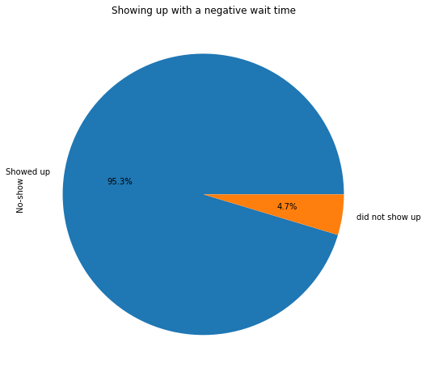

```python
counts=df_NegativeWait['No-show'].value_counts()
labels=['Showed up','did not show up']
pieChart(title='Showing up with a negative wait time',entry=counts,labelsList=labels, figsize=(8,8))
```

95.3% of the patients with the illogic entry of Appointment date < scheduled date showed up. This is very strange to show up for an appointment scheduled after the scheduling time. To clean the dataset from this strange entry, we will work on a new dataframe containing only poistive wait time </br>

##### creation of the new dataframe with the positive waiting time

```python
df_positive=df2.query('AppointmentDay>=ScheduledDay')
df_positive.head()
```

|  | PatientId | AppointmentID | Gender | ScheduledDay | AppointmentDay | Age | Neighbourhood | Scholarship | Hipertension | Diabetes | Alcoholism | Handcap | SMS_received | No-show |
| --- | --- | --- | --- | --- | --- | --- | --- | --- | --- | --- | --- | --- | --- | --- |
| 5 | 9.598513e+13 | 5626772 | F | 2016-04-27 08:36:51+00:00 | 2016-04-29 00:00:00+00:00 | 76 | REPÚBLICA | 0 | 1 | 0 | 0 | 0 | 0 | No |
| 6 | 7.336882e+14 | 5630279 | F | 2016-04-27 15:05:12+00:00 | 2016-04-29 00:00:00+00:00 | 23 | GOIABEIRAS | 0 | 0 | 0 | 0 | 0 | 0 | Yes |
| 7 | 3.449833e+12 | 5630575 | F | 2016-04-27 15:39:58+00:00 | 2016-04-29 00:00:00+00:00 | 39 | GOIABEIRAS | 0 | 0 | 0 | 0 | 0 | 0 | Yes |
| 9 | 7.812456e+13 | 5629123 | F | 2016-04-27 12:48:25+00:00 | 2016-04-29 00:00:00+00:00 | 19 | CONQUISTA | 0 | 0 | 0 | 0 | 0 | 0 | No |
| 10 | 7.345362e+14 | 5630213 | F | 2016-04-27 14:58:11+00:00 | 2016-04-29 00:00:00+00:00 | 30 | NOVA PALESTINA | 0 | 0 | 0 | 0 | 0 | 0 | No |

##### change the logic of No-show column as it is very confusing to work on double negative logic

We will re-encode it later to show column with </br> 1 for No(no-NoShow==Show) </br> 0 for Yes(yes-NoShow=Did not show up).

```python
df_positive['No-show']=df_positive['No-show'].map({'No':'1','Yes':'0'},na_action=None)
```

Rename 'No-show' column to 'Show' column

```python
df_positive.rename(columns={'No-show':'Show'},inplace=True)
```

```python
df_positive.head()
```

|  | PatientId | AppointmentID | Gender | ScheduledDay | AppointmentDay | Age | Neighbourhood | Scholarship | Hipertension | Diabetes | Alcoholism | Handcap | SMS_received | Show |
| --- | --- | --- | --- | --- | --- | --- | --- | --- | --- | --- | --- | --- | --- | --- |
| 5 | 9.598513e+13 | 5626772 | F | 2016-04-27 08:36:51+00:00 | 2016-04-29 00:00:00+00:00 | 76 | REPÚBLICA | 0 | 1 | 0 | 0 | 0 | 0 | 1 |
| 6 | 7.336882e+14 | 5630279 | F | 2016-04-27 15:05:12+00:00 | 2016-04-29 00:00:00+00:00 | 23 | GOIABEIRAS | 0 | 0 | 0 | 0 | 0 | 0 | 0 |
| 7 | 3.449833e+12 | 5630575 | F | 2016-04-27 15:39:58+00:00 | 2016-04-29 00:00:00+00:00 | 39 | GOIABEIRAS | 0 | 0 | 0 | 0 | 0 | 0 | 0 |
| 9 | 7.812456e+13 | 5629123 | F | 2016-04-27 12:48:25+00:00 | 2016-04-29 00:00:00+00:00 | 19 | CONQUISTA | 0 | 0 | 0 | 0 | 0 | 0 | 1 |
| 10 | 7.345362e+14 | 5630213 | F | 2016-04-27 14:58:11+00:00 | 2016-04-29 00:00:00+00:00 | 30 | NOVA PALESTINA | 0 | 0 | 0 | 0 | 0 | 0 | 1 |

change the Show column values to numeric

```python
df_positive.Show=pd.to_numeric(df_positive.Show)
```

```python
df_positive.head()
```

|  | PatientId | AppointmentID | Gender | ScheduledDay | AppointmentDay | Age | Neighbourhood | Scholarship | Hipertension | Diabetes | Alcoholism | Handcap | SMS_received | Show |
| --- | --- | --- | --- | --- | --- | --- | --- | --- | --- | --- | --- | --- | --- | --- |
| 5 | 9.598513e+13 | 5626772 | F | 2016-04-27 08:36:51+00:00 | 2016-04-29 00:00:00+00:00 | 76 | REPÚBLICA | 0 | 1 | 0 | 0 | 0 | 0 | 1 |
| 6 | 7.336882e+14 | 5630279 | F | 2016-04-27 15:05:12+00:00 | 2016-04-29 00:00:00+00:00 | 23 | GOIABEIRAS | 0 | 0 | 0 | 0 | 0 | 0 | 0 |
| 7 | 3.449833e+12 | 5630575 | F | 2016-04-27 15:39:58+00:00 | 2016-04-29 00:00:00+00:00 | 39 | GOIABEIRAS | 0 | 0 | 0 | 0 | 0 | 0 | 0 |
| 9 | 7.812456e+13 | 5629123 | F | 2016-04-27 12:48:25+00:00 | 2016-04-29 00:00:00+00:00 | 19 | CONQUISTA | 0 | 0 | 0 | 0 | 0 | 0 | 1 |
| 10 | 7.345362e+14 | 5630213 | F | 2016-04-27 14:58:11+00:00 | 2016-04-29 00:00:00+00:00 | 30 | NOVA PALESTINA | 0 | 0 | 0 | 0 | 0 | 0 | 1 |

```python
df_positive.info()
```

```
<class 'pandas.core.frame.DataFrame'>
Int64Index: 71959 entries, 5 to 110526
Data columns (total 14 columns):
 #   Column          Non-Null Count  Dtype
---  ------          --------------  -----
 0   PatientId       71959 non-null  float64
 1   AppointmentID   71959 non-null  int64
 2   Gender          71959 non-null  object
 3   ScheduledDay    71959 non-null  datetime64[ns, UTC]
 4   AppointmentDay  71959 non-null  datetime64[ns, UTC]
 5   Age             71959 non-null  int64
 6   Neighbourhood   71959 non-null  object
 7   Scholarship     71959 non-null  int64
 8   Hipertension    71959 non-null  int64
 9   Diabetes        71959 non-null  int64
 10  Alcoholism      71959 non-null  int64
 11  Handcap         71959 non-null  int64
 12  SMS_received    71959 non-null  int64
 13  Show            71959 non-null  int64
dtypes: datetime64[ns, UTC](2), float64(1), int64(9), object(2)
memory usage: 8.2+ MB
```

```python
df_positive.describe()
```

|  | PatientId | AppointmentID | Age | Scholarship | Hipertension | Diabetes | Alcoholism | Handcap | SMS_received | Show |
| --- | --- | --- | --- | --- | --- | --- | --- | --- | --- | --- |
| count | 7.195900e+04 | 7.195900e+04 | 71959.000000 | 71959.000000 | 71959.000000 | 71959.000000 | 71959.000000 | 71959.000000 | 71959.000000 | 71959.000000 |
| mean | 1.452606e+14 | 5.655042e+06 | 38.502564 | 0.092706 | 0.208897 | 0.074723 | 0.025320 | 0.020025 | 0.493086 | 0.714810 |
| std | 2.535667e+14 | 7.472189e+04 | 22.925421 | 0.290021 | 0.406523 | 0.262946 | 0.157096 | 0.154072 | 0.499956 | 0.451508 |
| min | 3.921784e+04 | 5.030230e+06 | 0.000000 | 0.000000 | 0.000000 | 0.000000 | 0.000000 | 0.000000 | 0.000000 | 0.000000 |
| 25% | 3.968099e+12 | 5.617796e+06 | 19.000000 | 0.000000 | 0.000000 | 0.000000 | 0.000000 | 0.000000 | 0.000000 | 0.000000 |
| 50% | 2.991891e+13 | 5.661165e+06 | 39.000000 | 0.000000 | 0.000000 | 0.000000 | 0.000000 | 0.000000 | 0.000000 | 1.000000 |
| 75% | 9.371660e+13 | 5.707178e+06 | 57.000000 | 0.000000 | 0.000000 | 0.000000 | 0.000000 | 0.000000 | 1.000000 | 1.000000 |
| max | 9.999320e+14 | 5.784985e+06 | 115.000000 | 1.000000 | 1.000000 | 1.000000 | 1.000000 | 4.000000 | 1.000000 | 1.000000 |

##### create a new column for special cases (Hipertension, Diabetes, Alcoholism, Handcap)

We need to be careful as there are 4 levels in Handcap column.

```python
SpecialCase=df_positive['Hipertension']+df_positive['Diabetes']+df_positive['Alcoholism'] >=1
```

```python
SpecialCase=SpecialCase | df_positive['Handcap']>=1
```

```python
print(SpecialCase)
```

```
5          True
6         False
7         False
9         False
10        False
          ...
110522    False
110523    False
110524    False
110525    False
110526    False
Length: 71959, dtype: bool
```

```python
df_positive.insert(8, 'SpecialCase',SpecialCase)
```

```python
df_positive.head()
```

|  | PatientId | AppointmentID | Gender | ScheduledDay | AppointmentDay | Age | Neighbourhood | Scholarship | SpecialCase | Hipertension | Diabetes | Alcoholism | Handcap | SMS_received | Show |
| --- | --- | --- | --- | --- | --- | --- | --- | --- | --- | --- | --- | --- | --- | --- | --- |
| 5 | 9.598513e+13 | 5626772 | F | 2016-04-27 08:36:51+00:00 | 2016-04-29 00:00:00+00:00 | 76 | REPÚBLICA | 0 | True | 1 | 0 | 0 | 0 | 0 | 1 |
| 6 | 7.336882e+14 | 5630279 | F | 2016-04-27 15:05:12+00:00 | 2016-04-29 00:00:00+00:00 | 23 | GOIABEIRAS | 0 | False | 0 | 0 | 0 | 0 | 0 | 0 |
| 7 | 3.449833e+12 | 5630575 | F | 2016-04-27 15:39:58+00:00 | 2016-04-29 00:00:00+00:00 | 39 | GOIABEIRAS | 0 | False | 0 | 0 | 0 | 0 | 0 | 0 |
| 9 | 7.812456e+13 | 5629123 | F | 2016-04-27 12:48:25+00:00 | 2016-04-29 00:00:00+00:00 | 19 | CONQUISTA | 0 | False | 0 | 0 | 0 | 0 | 0 | 1 |
| 10 | 7.345362e+14 | 5630213 | F | 2016-04-27 14:58:11+00:00 | 2016-04-29 00:00:00+00:00 | 30 | NOVA PALESTINA | 0 | False | 0 | 0 | 0 | 0 | 0 | 1 |

Change the SpecialCase column to numeric to be the same as other columns and check the charistics of the final dataframe that we are going to analyse

```python
df_positive['SpecialCase']=df_positive['SpecialCase'].map({False:0,True:1},na_action=None)
```

```python
df_positive.info()
```

```
<class 'pandas.core.frame.DataFrame'>
Int64Index: 71959 entries, 5 to 110526
Data columns (total 15 columns):
 #   Column          Non-Null Count  Dtype
---  ------          --------------  -----
 0   PatientId       71959 non-null  float64
 1   AppointmentID   71959 non-null  int64
 2   Gender          71959 non-null  object
 3   ScheduledDay    71959 non-null  datetime64[ns, UTC]
 4   AppointmentDay  71959 non-null  datetime64[ns, UTC]
 5   Age             71959 non-null  int64
 6   Neighbourhood   71959 non-null  object
 7   Scholarship     71959 non-null  int64
 8   SpecialCase     71959 non-null  int64
 9   Hipertension    71959 non-null  int64
 10  Diabetes        71959 non-null  int64
 11  Alcoholism      71959 non-null  int64
 12  Handcap         71959 non-null  int64
 13  SMS_received    71959 non-null  int64
 14  Show            71959 non-null  int64
dtypes: datetime64[ns, UTC](2), float64(1), int64(10), object(2)
memory usage: 8.8+ MB
```

```python
df_positive.head()
```

|  | PatientId | AppointmentID | Gender | ScheduledDay | AppointmentDay | Age | Neighbourhood | Scholarship | SpecialCase | Hipertension | Diabetes | Alcoholism | Handcap | SMS_received | Show |
| --- | --- | --- | --- | --- | --- | --- | --- | --- | --- | --- | --- | --- | --- | --- | --- |
| 5 | 9.598513e+13 | 5626772 | F | 2016-04-27 08:36:51+00:00 | 2016-04-29 00:00:00+00:00 | 76 | REPÚBLICA | 0 | 1 | 1 | 0 | 0 | 0 | 0 | 1 |
| 6 | 7.336882e+14 | 5630279 | F | 2016-04-27 15:05:12+00:00 | 2016-04-29 00:00:00+00:00 | 23 | GOIABEIRAS | 0 | 0 | 0 | 0 | 0 | 0 | 0 | 0 |
| 7 | 3.449833e+12 | 5630575 | F | 2016-04-27 15:39:58+00:00 | 2016-04-29 00:00:00+00:00 | 39 | GOIABEIRAS | 0 | 0 | 0 | 0 | 0 | 0 | 0 | 0 |
| 9 | 7.812456e+13 | 5629123 | F | 2016-04-27 12:48:25+00:00 | 2016-04-29 00:00:00+00:00 | 19 | CONQUISTA | 0 | 0 | 0 | 0 | 0 | 0 | 0 | 1 |
| 10 | 7.345362e+14 | 5630213 | F | 2016-04-27 14:58:11+00:00 | 2016-04-29 00:00:00+00:00 | 30 | NOVA PALESTINA | 0 | 0 | 0 | 0 | 0 | 0 | 0 | 1 |

```python
df_positive.describe(include='all')
```

|  | PatientId | AppointmentID | Gender | ScheduledDay | AppointmentDay | Age | Neighbourhood | Scholarship | SpecialCase | Hipertension | Diabetes | Alcoholism | Handcap | SMS_received | Show |
| --- | --- | --- | --- | --- | --- | --- | --- | --- | --- | --- | --- | --- | --- | --- | --- |
| count | 7.195900e+04 | 7.195900e+04 | 71959 | 71959 | 71959 | 71959.000000 | 71959 | 71959.000000 | 71959.000000 | 71959.000000 | 71959.000000 | 71959.000000 | 71959.000000 | 71959.000000 | 71959.000000 |
| unique | NaN | NaN | 2 | 68666 | 27 | NaN | 80 | NaN | NaN | NaN | NaN | NaN | NaN | NaN | NaN |
| top | NaN | NaN | F | 2016-04-25 17:17:46+00:00 | 2016-06-06 00:00:00+00:00 | NaN | JARDIM CAMBURI | NaN | NaN | NaN | NaN | NaN | NaN | NaN | NaN |
| freq | NaN | NaN | 48070 | 22 | 3073 | NaN | 5213 | NaN | NaN | NaN | NaN | NaN | NaN | NaN | NaN |
| first | NaN | NaN | NaN | 2015-11-10 07:13:56+00:00 | 2016-04-29 00:00:00+00:00 | NaN | NaN | NaN | NaN | NaN | NaN | NaN | NaN | NaN | NaN |
| last | NaN | NaN | NaN | 2016-06-07 19:03:57+00:00 | 2016-06-08 00:00:00+00:00 | NaN | NaN | NaN | NaN | NaN | NaN | NaN | NaN | NaN | NaN |
| mean | 1.452606e+14 | 5.655042e+06 | NaN | NaN | NaN | 38.502564 | NaN | 0.092706 | 0.245418 | 0.208897 | 0.074723 | 0.025320 | 0.020025 | 0.493086 | 0.714810 |
| std | 2.535667e+14 | 7.472189e+04 | NaN | NaN | NaN | 22.925421 | NaN | 0.290021 | 0.430337 | 0.406523 | 0.262946 | 0.157096 | 0.154072 | 0.499956 | 0.451508 |
| min | 3.921784e+04 | 5.030230e+06 | NaN | NaN | NaN | 0.000000 | NaN | 0.000000 | 0.000000 | 0.000000 | 0.000000 | 0.000000 | 0.000000 | 0.000000 | 0.000000 |
| 25% | 3.968099e+12 | 5.617796e+06 | NaN | NaN | NaN | 19.000000 | NaN | 0.000000 | 0.000000 | 0.000000 | 0.000000 | 0.000000 | 0.000000 | 0.000000 | 0.000000 |
| 50% | 2.991891e+13 | 5.661165e+06 | NaN | NaN | NaN | 39.000000 | NaN | 0.000000 | 0.000000 | 0.000000 | 0.000000 | 0.000000 | 0.000000 | 0.000000 | 1.000000 |
| 75% | 9.371660e+13 | 5.707178e+06 | NaN | NaN | NaN | 57.000000 | NaN | 0.000000 | 0.000000 | 0.000000 | 0.000000 | 0.000000 | 0.000000 | 1.000000 | 1.000000 |
| max | 9.999320e+14 | 5.784985e+06 | NaN | NaN | NaN | 115.000000 | NaN | 1.000000 | 1.000000 | 1.000000 | 1.000000 | 1.000000 | 4.000000 | 1.000000 | 1.000000 |

##### Create a new column for age categories to check later if a special category does not show up for appointments </br>

The first 25% of Age feature value is 19. To not to add 2 columns to the dataframa((Minor, Major),(age categories)), we will add only one column where the first age category is for minors. The other categories will be chosen based on 50%,75% and max.

```python
categoriesEdges=[0,18,40,60,115]
categoriesNames=['Minor','middleAge','old', 'retired']
df_positive['AgeCategories']=pd.cut(df_positive['Age'],categoriesEdges,labels=categoriesNames)
```

```python
df_positive.head()
```

|  | PatientId | AppointmentID | Gender | ScheduledDay | AppointmentDay | Age | Neighbourhood | Scholarship | SpecialCase | Hipertension | Diabetes | Alcoholism | Handcap | SMS_received | Show | AgeCategories |
| --- | --- | --- | --- | --- | --- | --- | --- | --- | --- | --- | --- | --- | --- | --- | --- | --- |
| 5 | 9.598513e+13 | 5626772 | F | 2016-04-27 08:36:51+00:00 | 2016-04-29 00:00:00+00:00 | 76 | REPÚBLICA | 0 | 1 | 1 | 0 | 0 | 0 | 0 | 1 | retired |
| 6 | 7.336882e+14 | 5630279 | F | 2016-04-27 15:05:12+00:00 | 2016-04-29 00:00:00+00:00 | 23 | GOIABEIRAS | 0 | 0 | 0 | 0 | 0 | 0 | 0 | 0 | middleAge |
| 7 | 3.449833e+12 | 5630575 | F | 2016-04-27 15:39:58+00:00 | 2016-04-29 00:00:00+00:00 | 39 | GOIABEIRAS | 0 | 0 | 0 | 0 | 0 | 0 | 0 | 0 | middleAge |
| 9 | 7.812456e+13 | 5629123 | F | 2016-04-27 12:48:25+00:00 | 2016-04-29 00:00:00+00:00 | 19 | CONQUISTA | 0 | 0 | 0 | 0 | 0 | 0 | 0 | 1 | middleAge |
| 10 | 7.345362e+14 | 5630213 | F | 2016-04-27 14:58:11+00:00 | 2016-04-29 00:00:00+00:00 | 30 | NOVA PALESTINA | 0 | 0 | 0 | 0 | 0 | 0 | 0 | 1 | middleAge |

## Exploratory Data Analysis

Before making a research for each question, let's draw general charts

##### Pie chart to understand the general percentage of people who do not show up for their appointments

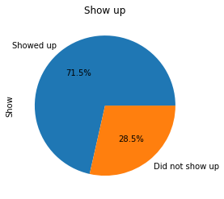

```python
counts=df_positive['Show'].value_counts()
labels=['Showed up', 'Did not show up']
pieChart(title='Show up',entry=counts, labelsList=labels,figsize=(4,4))
```

There are 28.5% of patients in our dataframe who does not show up for appointments. We wiil try to anlayze related factors. </br>

##### General historgram charts

This will be drawn just to check th general distribution of the deferant elements present in the dataset

[output not shown]

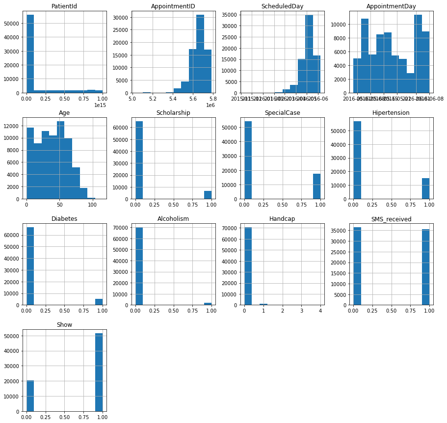

```python
df_positive.hist(figsize=(15,15))
```

##### Check general correlation

We will:

1. draw a scrater matrix
2. load the correlation table
3. use the correlation table to draw a heatmap and get a general idea about the correlation betweeen the dataset elements

```
<function matplotlib.pyplot.show(close=None, block=None)>
```

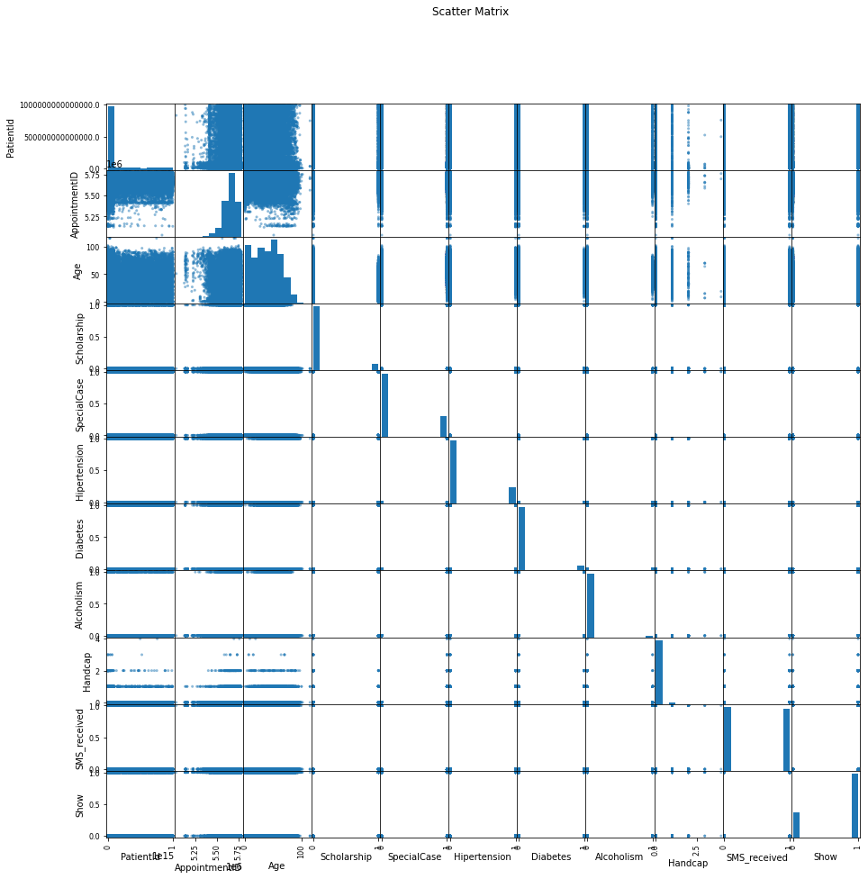

```python
pd.plotting.scatter_matrix(df_positive,figsize=(15,15))
plt.suptitle('Scatter Matrix')
plt.show
```

```python
correlation=df_positive.corr()
correlation
```

|  | PatientId | AppointmentID | Age | Scholarship | SpecialCase | Hipertension | Diabetes | Alcoholism | Handcap | SMS_received | Show |
| --- | --- | --- | --- | --- | --- | --- | --- | --- | --- | --- | --- |
| PatientId | 1.000000 | -0.003452 | -0.004761 | -0.001842 | -0.001508 | -0.002550 | -0.000153 | 0.005210 | -0.003985 | -0.005427 | -0.003342 |
| AppointmentID | -0.003452 | 1.000000 | 0.019069 | 0.017534 | 0.055210 | 0.043821 | 0.040145 | 0.025299 | 0.011384 | -0.083738 | 0.065723 |
| Age | -0.004761 | 0.019069 | 1.000000 | -0.103038 | 0.502848 | 0.500749 | 0.284477 | 0.080350 | 0.077141 | -0.042537 | 0.101042 |
| Scholarship | -0.001842 | 0.017534 | -0.103038 | 1.000000 | -0.016277 | -0.027764 | -0.025417 | 0.030529 | -0.010446 | 0.020666 | -0.045687 |
| SpecialCase | -0.001508 | 0.055210 | 0.502848 | -0.016277 | 1.000000 | 0.901052 | 0.498301 | 0.282619 | 0.227908 | -0.043529 | 0.047238 |
| Hipertension | -0.002550 | 0.043821 | 0.500749 | -0.027764 | 0.901052 | 1.000000 | 0.425614 | 0.085821 | 0.083643 | -0.037065 | 0.056859 |
| Diabetes | -0.000153 | 0.040145 | 0.284477 | -0.025417 | 0.498301 | 0.425614 | 1.000000 | 0.024174 | 0.061513 | -0.031219 | 0.022412 |
| Alcoholism | 0.005210 | 0.025299 | 0.080350 | 0.030529 | 0.282619 | 0.085821 | 0.024174 | 1.000000 | 0.013501 | -0.009095 | -0.019864 |
| Handcap | -0.003985 | 0.011384 | 0.077141 | -0.010446 | 0.227908 | 0.083643 | 0.061513 | 0.013501 | 1.000000 | -0.022107 | 0.007184 |
| SMS_received | -0.005427 | -0.083738 | -0.042537 | 0.020666 | -0.043529 | -0.037065 | -0.031219 | -0.009095 | -0.022107 | 1.000000 | 0.020631 |
| Show | -0.003342 | 0.065723 | 0.101042 | -0.045687 | 0.047238 | 0.056859 | 0.022412 | -0.019864 | 0.007184 | 0.020631 | 1.000000 |

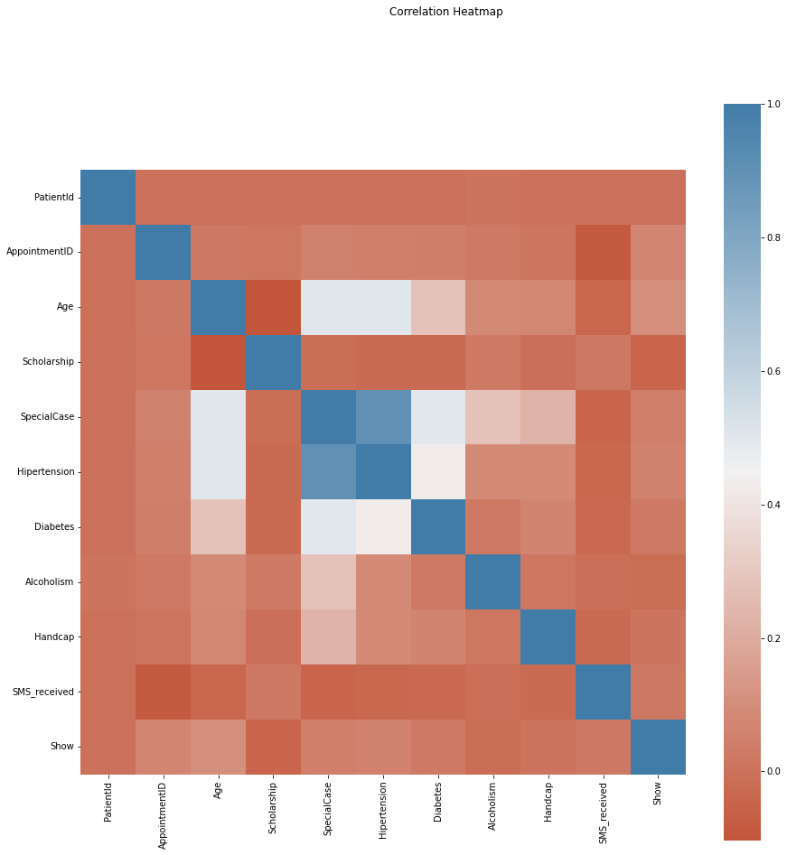

```python
fig, ax = plt.subplots(figsize=(15,15))
sns.heatmap(correlation,
            cmap=sns.diverging_palette(740,600, as_cmap=True),
            square=True,
            ax=ax)
fig.suptitle('Correlation Heatmap')
plt.show()
```

Per the correlation graph, the age seems to be the most correlated to patients attandance

### Research Question 1

- Are same patients always showing up to their appointments?
- Are there some patients who have never showed up to their appointments and others who have always showed up?

Get the mean of Show per patient then draw a bar chart to check if there are some patients who have always show up and others who have never showed up to their appointments As we may need to use a bar chart later, let's create a fundction for it first of all.

```python
def barChart(title, entry, figsize,x,y):
    entry.plot(kind='bar', figsize=figsize)
    plt.title(title)
    plt.xlabel(x)
    plt.ylabel(y)
    plt.show
```

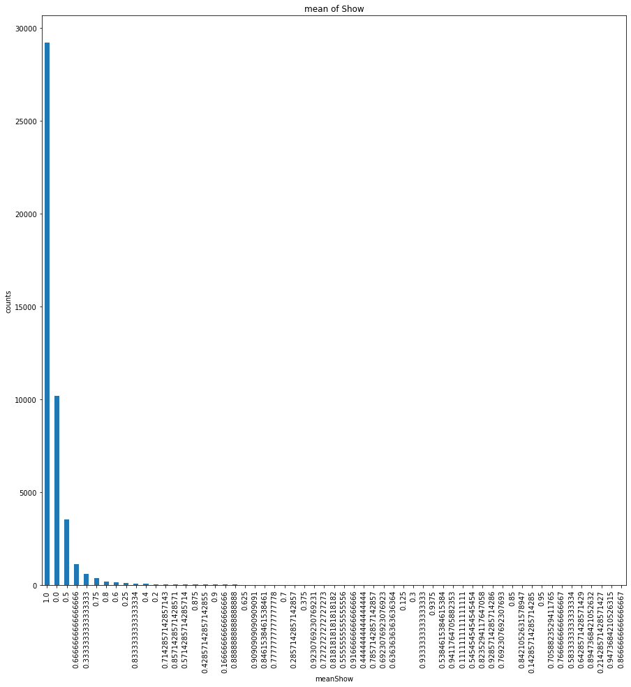

```python
#calculate mean of Show per Patien
meanShow=df_positive.groupby('PatientId',as_index=False)['Show'].mean()
#draw a bar chart
counts=meanShow['Show'].value_counts()
barChart('mean of Show',counts,(15,15),'meanShow','counts')
```

Our intuition was right. There are patients who are consistent in their show-up behavour. To get exact values, let's draw a pie chart to get rates of the mean of Show per patient. As there are several values for labels, we will create a similar fundction to pieChart with ne labels entries.

```python
def pieChart2(title,entry,figsize):
    entry.plot(kind='pie',autopct='%1.1f%%',figsize=figsize)
    plt.title(title)
    plt.show
```

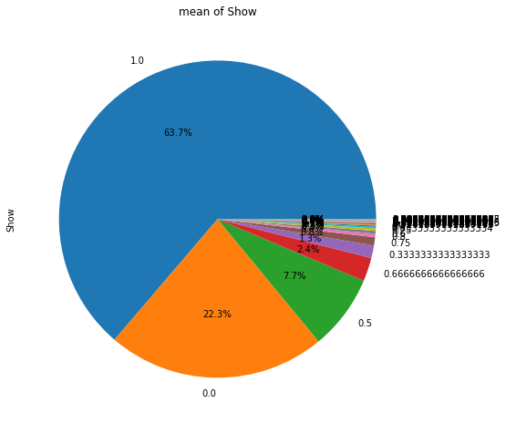

```python
pieChart2('mean of Show',counts,(8,8))
```

63.7% of patients show up always for their appointments. Meanwhile, 22.3% of patients have never showed up. 7.7% of patient show up half of the time

### Research Question 2 Age distribution for those who show up and who do not ((Minor-Major) or (age gap))

First of all, let's draw a histogram to check the distribution of age of patients who shows and those who does not without the usage of categories

```
<function matplotlib.pyplot.show(close=None, block=None)>
```

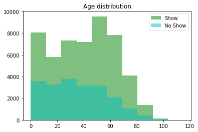

```python
ageShow=df_positive.query('Show==1')
plt.hist(ageShow.Age,color='g', alpha=0.5,label='Show')
ageNoShow=df_positive.query('Show==0')
plt.hist(ageNoShow.Age,color='c', alpha=0.5,label='No Show')
plt.title('Age distribution')
plt.xlabel='Age'
plt.ylabel='counts'
plt.legend()
plt.show
```

This dataset contains more people whose age is less than 60. We cannot give an answer to our question as showing up patients are dominant. Let's draw a bar chart for the age categories depending on Show Values so perhaps we can get an answers by comparing each bar to others.

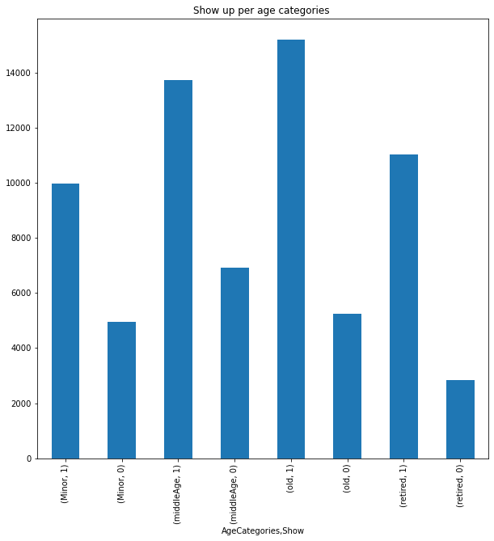

```python
counts=df_positive.groupby('AgeCategories')['Show'].value_counts()
#in this chart the xlabel and ylabel are not callableWe will define a new bar chart function where we do not need to enter xlabel:
def barChart2(title, entry, figsize):
    entry.plot(kind='bar', figsize=figsize)
    plt.title(title)
    plt.show
#Now let's call it and draw our bar chart
barChart2('Show up per age categories ',counts, (10,10))
```

The rate of not showing up compared to showing up between some categoies is very closeLet's draw a pie chart to get more precise information

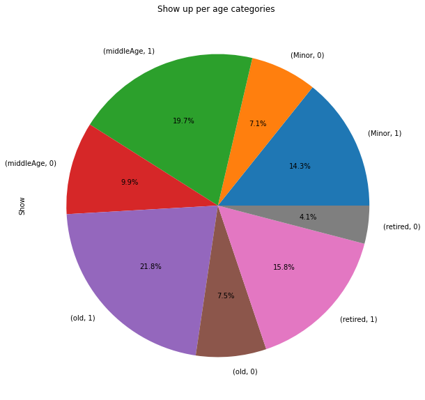

```python
pieChart2('Show up per age categories ',counts, (10,10))
```

We can notice that the dataset contains more data about people aged between 18 and 60. The middleAge category (between 18 and 40) are the least to show up for an appointments. It could be a work related constraint. Then, we have Minor cateegory. It could be related to their need for someone to go with them who will belong to the middleAge category. </br>

### Research Question 3: Does receiving SMS impacts the arrival of patients?

Lets draw a bar chart to check the patients who showed up depending on sms receival

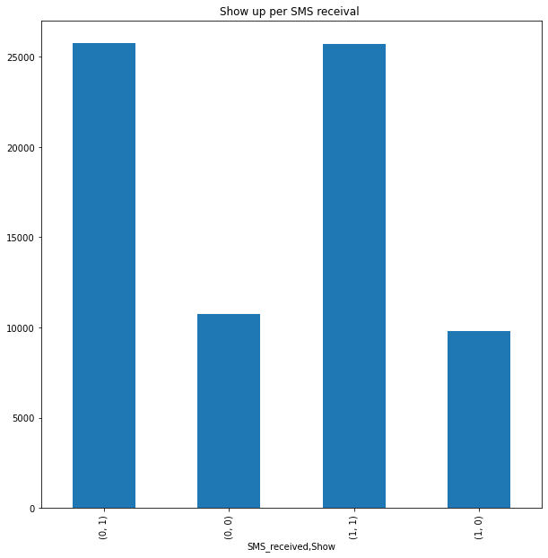

```python
counts=df_positive.groupby('SMS_received')['Show'].value_counts()
barChart2('Show up per SMS receival ',counts, (10,10))
```

It feels like receiving an SMS does not encourage or remind patients to show up for their appointments. Hopefully, that the system does not send the SMS after the appointment date as patients can take an appointment date before the schedule date. </br>

### Research Question 4: Is showing up higher with a specific gender?

Lets draw a bar chart to check the patients who showed up depending on their gender

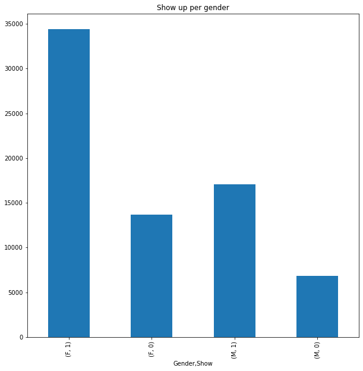

```python
counts=df_positive.groupby('Gender')['Show'].value_counts()
barChart2('Show up per gender',counts, (10,10))
```

We can notice that the rate of female is higher in this dataset.</br> let's analyze each gender alone using pie charts. We will use pie charts so we can compare using a precise rate </br> Pie chart for Female gender:

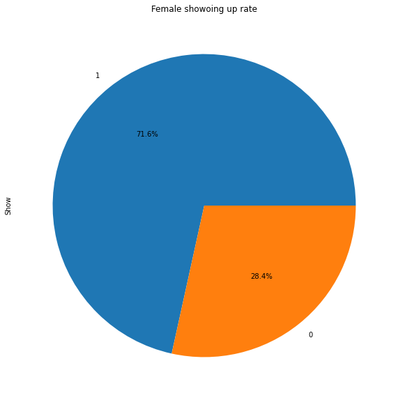

```python
counts=df_positive.query('Gender=="F"')['Show'].value_counts()
pieChart2('Female showoing up rate',counts, (10,10))
```

Pie chart for male gender:

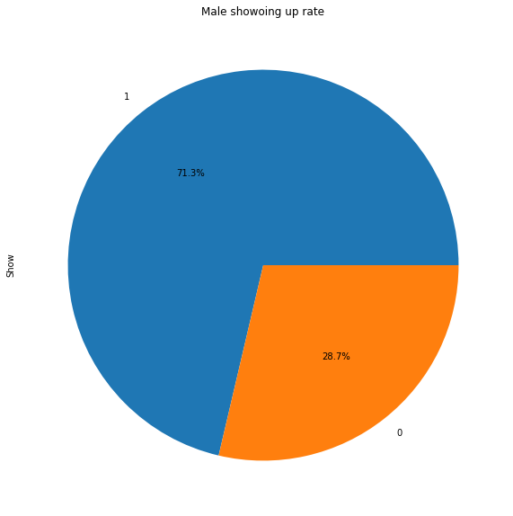

```python
counts=df_positive.query('Gender=="M"')['Show'].value_counts()
pieChart2('Male showoing up rate',counts, (10,10))
```

Gender does not affect showing up for the appointment. It is almost the same rate for showing up and not showing up for both gender.</br>

### Research Question 5: Does the duration between the scheduling day and the appointment day impacts the rate of people showing up?

Let's check first of all the difference between the scheduling day and the appointment day per days.</br> First we wiil calculate the round difference per day. Then add it to a temp dataframe to check its chracteristics and decide on duration intervals to be analyzed

```python
df_temp=df_positive.copy()
diff=df_positive.AppointmentDay - df_positive.ScheduledDay
diff=round(diff/np.timedelta64(1,'D'))
df_temp['diff']=diff
df_temp.head()
```

|  | PatientId | AppointmentID | Gender | ScheduledDay | AppointmentDay | Age | Neighbourhood | Scholarship | SpecialCase | Hipertension | Diabetes | Alcoholism | Handcap | SMS_received | Show | AgeCategories | diff |
| --- | --- | --- | --- | --- | --- | --- | --- | --- | --- | --- | --- | --- | --- | --- | --- | --- | --- |
| 5 | 9.598513e+13 | 5626772 | F | 2016-04-27 08:36:51+00:00 | 2016-04-29 00:00:00+00:00 | 76 | REPÚBLICA | 0 | 1 | 1 | 0 | 0 | 0 | 0 | 1 | retired | 2.0 |
| 6 | 7.336882e+14 | 5630279 | F | 2016-04-27 15:05:12+00:00 | 2016-04-29 00:00:00+00:00 | 23 | GOIABEIRAS | 0 | 0 | 0 | 0 | 0 | 0 | 0 | 0 | middleAge | 1.0 |
| 7 | 3.449833e+12 | 5630575 | F | 2016-04-27 15:39:58+00:00 | 2016-04-29 00:00:00+00:00 | 39 | GOIABEIRAS | 0 | 0 | 0 | 0 | 0 | 0 | 0 | 0 | middleAge | 1.0 |
| 9 | 7.812456e+13 | 5629123 | F | 2016-04-27 12:48:25+00:00 | 2016-04-29 00:00:00+00:00 | 19 | CONQUISTA | 0 | 0 | 0 | 0 | 0 | 0 | 0 | 1 | middleAge | 1.0 |
| 10 | 7.345362e+14 | 5630213 | F | 2016-04-27 14:58:11+00:00 | 2016-04-29 00:00:00+00:00 | 30 | NOVA PALESTINA | 0 | 0 | 0 | 0 | 0 | 0 | 0 | 1 | middleAge | 1.0 |

```python
df_temp.describe(include='all')
```

|  | PatientId | AppointmentID | Gender | ScheduledDay | AppointmentDay | Age | Neighbourhood | Scholarship | SpecialCase | Hipertension | Diabetes | Alcoholism | Handcap | SMS_received | Show | AgeCategories | diff |
| --- | --- | --- | --- | --- | --- | --- | --- | --- | --- | --- | --- | --- | --- | --- | --- | --- | --- |
| count | 7.195900e+04 | 7.195900e+04 | 71959 | 71959 | 71959 | 71959.000000 | 71959 | 71959.000000 | 71959.000000 | 71959.000000 | 71959.000000 | 71959.000000 | 71959.000000 | 71959.000000 | 71959.000000 | 69828 | 71959.000000 |
| unique | NaN | NaN | 2 | 68666 | 27 | NaN | 80 | NaN | NaN | NaN | NaN | NaN | NaN | NaN | NaN | 4 | NaN |
| top | NaN | NaN | F | 2016-04-25 17:17:46+00:00 | 2016-06-06 00:00:00+00:00 | NaN | JARDIM CAMBURI | NaN | NaN | NaN | NaN | NaN | NaN | NaN | NaN | middleAge | NaN |
| freq | NaN | NaN | 48070 | 22 | 3073 | NaN | 5213 | NaN | NaN | NaN | NaN | NaN | NaN | NaN | NaN | 20643 | NaN |
| first | NaN | NaN | NaN | 2015-11-10 07:13:56+00:00 | 2016-04-29 00:00:00+00:00 | NaN | NaN | NaN | NaN | NaN | NaN | NaN | NaN | NaN | NaN | NaN | NaN |
| last | NaN | NaN | NaN | 2016-06-07 19:03:57+00:00 | 2016-06-08 00:00:00+00:00 | NaN | NaN | NaN | NaN | NaN | NaN | NaN | NaN | NaN | NaN | NaN | NaN |
| mean | 1.452606e+14 | 5.655042e+06 | NaN | NaN | NaN | 38.502564 | NaN | 0.092706 | 0.245418 | 0.208897 | 0.074723 | 0.025320 | 0.020025 | 0.493086 | 0.714810 | NaN | 15.226699 |
| std | 2.535667e+14 | 7.472189e+04 | NaN | NaN | NaN | 22.925421 | NaN | 0.290021 | 0.430337 | 0.406523 | 0.262946 | 0.157096 | 0.154072 | 0.499956 | 0.451508 | NaN | 16.500417 |
| min | 3.921784e+04 | 5.030230e+06 | NaN | NaN | NaN | 0.000000 | NaN | 0.000000 | 0.000000 | 0.000000 | 0.000000 | 0.000000 | 0.000000 | 0.000000 | 0.000000 | NaN | 0.000000 |
| 25% | 3.968099e+12 | 5.617796e+06 | NaN | NaN | NaN | 19.000000 | NaN | 0.000000 | 0.000000 | 0.000000 | 0.000000 | 0.000000 | 0.000000 | 0.000000 | 0.000000 | NaN | 4.000000 |
| 50% | 2.991891e+13 | 5.661165e+06 | NaN | NaN | NaN | 39.000000 | NaN | 0.000000 | 0.000000 | 0.000000 | 0.000000 | 0.000000 | 0.000000 | 0.000000 | 1.000000 | NaN | 9.000000 |
| 75% | 9.371660e+13 | 5.707178e+06 | NaN | NaN | NaN | 57.000000 | NaN | 0.000000 | 0.000000 | 0.000000 | 0.000000 | 0.000000 | 0.000000 | 1.000000 | 1.000000 | NaN | 22.000000 |
| max | 9.999320e+14 | 5.784985e+06 | NaN | NaN | NaN | 115.000000 | NaN | 1.000000 | 1.000000 | 1.000000 | 1.000000 | 1.000000 | 4.000000 | 1.000000 | 1.000000 | NaN | 179.000000 |

Let's draw a histogram diagram for the distribution of wait difference

```
<function matplotlib.pyplot.show(close=None, block=None)>
```

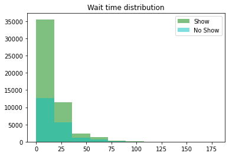

```python
diffShow=df_temp.query('Show==1')
plt.hist(diffShow['diff'],color='g', alpha=0.5,label='Show')
diffNoShow=df_temp.query('Show==0')
plt.hist(diffNoShow['diff'],color='c', alpha=0.5,label='No Show')
plt.title('Wait time distribution')
plt.xlabel='Wait time'
plt.ylabel='counts'
plt.legend()
plt.show
```

```python
durationEdges=[0,1,4,9,22,90,179]
```

```python
durationlabels=['oneDay','fewDays', 'week', 'month', 'threeMonths', 'longDestination']
```

```python
df_positive['Duration']=pd.cut(diff, durationEdges, labels=durationlabels)
df_positive.head()
```

|  | PatientId | AppointmentID | Gender | ScheduledDay | AppointmentDay | Age | Neighbourhood | Scholarship | SpecialCase | Hipertension | Diabetes | Alcoholism | Handcap | SMS_received | Show | AgeCategories | Duration |
| --- | --- | --- | --- | --- | --- | --- | --- | --- | --- | --- | --- | --- | --- | --- | --- | --- | --- |
| 5 | 9.598513e+13 | 5626772 | F | 2016-04-27 08:36:51+00:00 | 2016-04-29 00:00:00+00:00 | 76 | REPÚBLICA | 0 | 1 | 1 | 0 | 0 | 0 | 0 | 1 | retired | fewDays |
| 6 | 7.336882e+14 | 5630279 | F | 2016-04-27 15:05:12+00:00 | 2016-04-29 00:00:00+00:00 | 23 | GOIABEIRAS | 0 | 0 | 0 | 0 | 0 | 0 | 0 | 0 | middleAge | oneDay |
| 7 | 3.449833e+12 | 5630575 | F | 2016-04-27 15:39:58+00:00 | 2016-04-29 00:00:00+00:00 | 39 | GOIABEIRAS | 0 | 0 | 0 | 0 | 0 | 0 | 0 | 0 | middleAge | oneDay |
| 9 | 7.812456e+13 | 5629123 | F | 2016-04-27 12:48:25+00:00 | 2016-04-29 00:00:00+00:00 | 19 | CONQUISTA | 0 | 0 | 0 | 0 | 0 | 0 | 0 | 1 | middleAge | oneDay |
| 10 | 7.345362e+14 | 5630213 | F | 2016-04-27 14:58:11+00:00 | 2016-04-29 00:00:00+00:00 | 30 | NOVA PALESTINA | 0 | 0 | 0 | 0 | 0 | 0 | 0 | 1 | middleAge | oneDay |

Now let's draw a bar chart to check patients showing up rate based on the created categories.

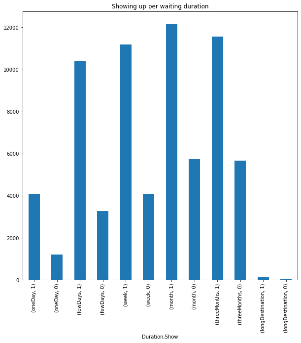

```python
counts=df_positive.groupby('Duration')['Show'].value_counts()
barChart2('Showing up per waiting duration',counts,(10,10))
```

We can notice that not showing up rate is close in some categories. Let's draw a pie chart to get more precise rates.

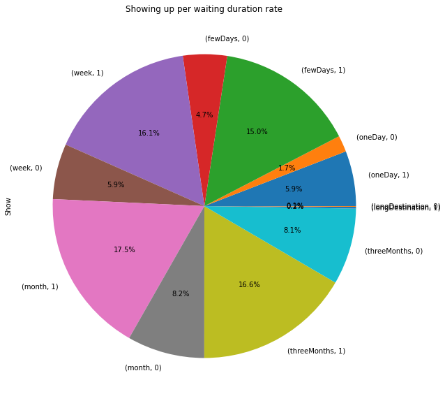

```python
pieChart2(title='Showing up per waiting duration rate',entry=counts, figsize=(10,10))
```

We can notice that patients have to wait a long period. Usually they need to wait a month and sometimes around three months. Some of them need to wait even more. We can notice that the longer the patients have to wait, the higher rate of them not showing up. Meanwhile, the patients who have to wait more than three months tend to show up more.

### Research Question 6: Do patients do not show up during specifc weekdays?

Let's draw a bar chart to check if patients tend to schedule appointments on specific weekdays and do not show up In Pandas, weekday are encoded from 0 to 6 which is from Monday to Sunday

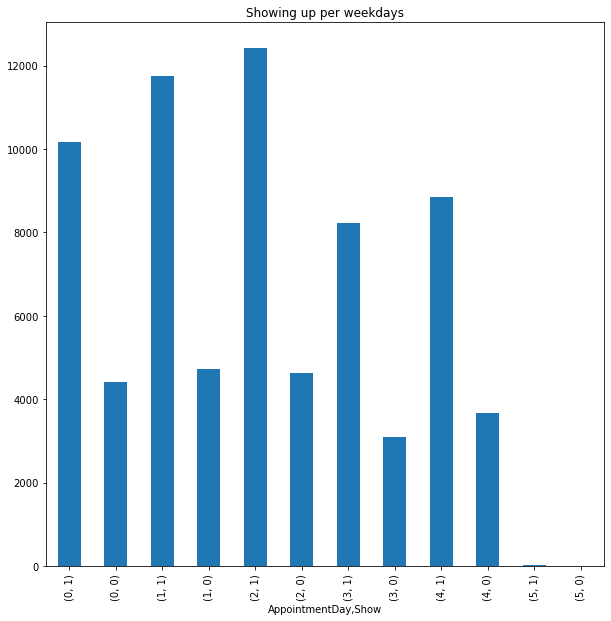

```python
dayOfWeek=df_positive.AppointmentDay.dt.dayofweek
counts=df_positive.groupby(dayOfWeek)['Show'].value_counts()
barChart2('Showing up per weekdays',counts,(10,10))
```

We can notice that not showing up rate is close in some weekdays. Let's draw a pie chart to get more precise rates.

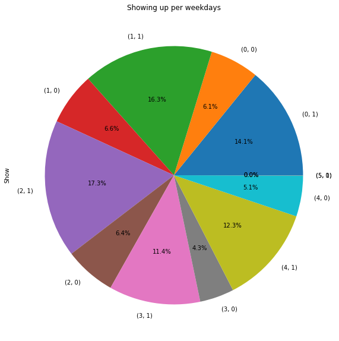

```python
pieChart2('Showing up per weekdays',counts,(10,10))
```

The patients are not scheduling appointments on Sunday and almost there are no appoinments on Saturday. The most of appointments are scheduled for Monday-Tuesday and Wednesday. We can notice the highest no-show up on these days. This can be explained as these are working days.

### Research Question 7:Do patients do not show up during some specific days?

Let's draw a line chart to check if patients do not show up during some specific days

```
<function matplotlib.pyplot.show(close=None, block=None)>
```

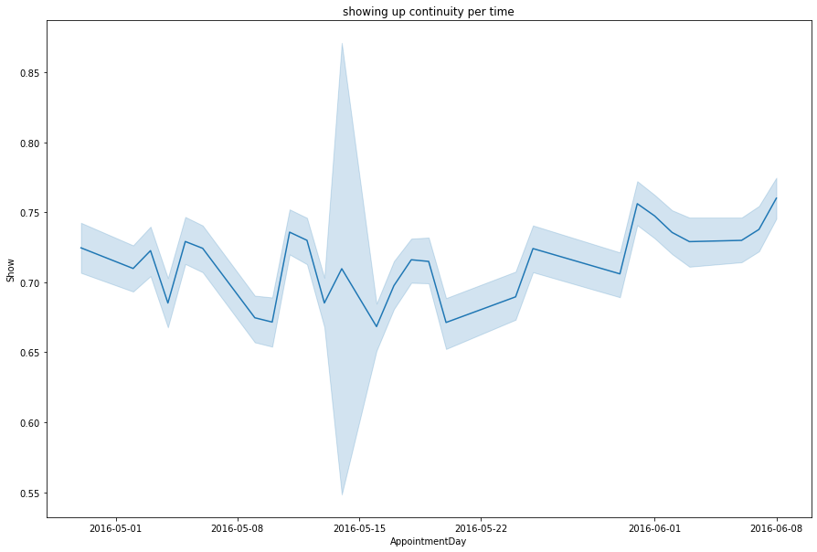

```python
fig, ax = plt.subplots(figsize=(15, 10))
sns.lineplot(data=df_positive,x='AppointmentDay', y='Show',ax=ax)
plt.title('showing up continuity per time')
plt.show
```

Based on this dataset, patients do not show up in a regular way. There is no sharp decrease. The highest rate of patients not showing up is in the second week of May.

### Research Question 8:Do patients enrolled in the scholarship have always showed up ?

Let's draw a bar chart to check if patients enrolled in the scholarship have always showed up or not

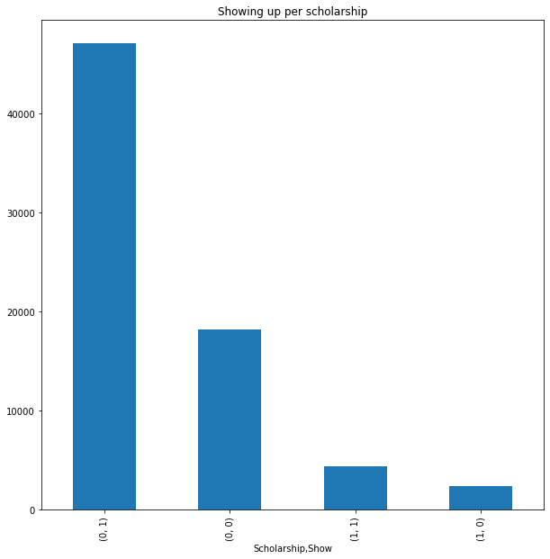

```python
counts=df_positive.groupby('Scholarship')['Show'].value_counts()
barChart2('Showing up per scholarship',counts,(10,10))
```

We can notice that the majority of patients are not enrolled in the scholarship. Hence we will need to analyze each case alone. Let's draw pie charts to get precise rates.

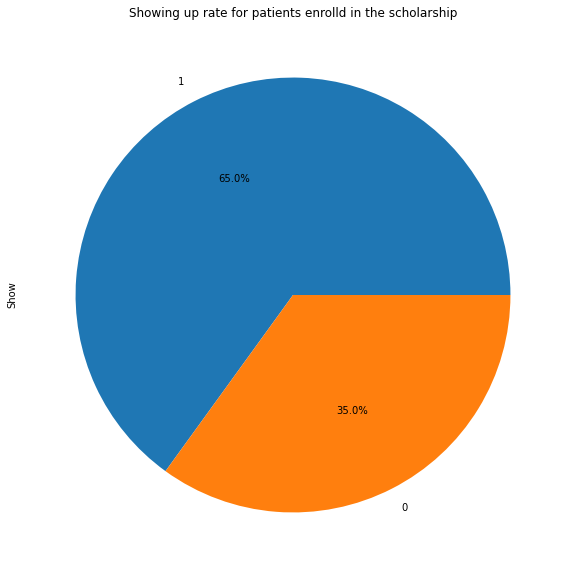

```python
counts=df_positive.query('Scholarship==1')['Show'].value_counts()
pieChart2('Showing up rate for patients enrolld in the scholarship',counts,(10,10))
```

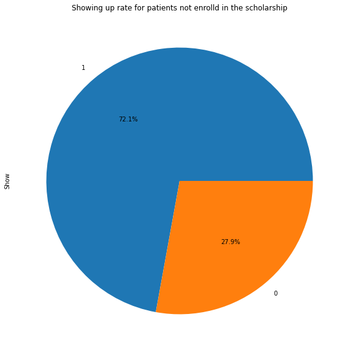

```python
counts=df_positive.query('Scholarship==0')['Show'].value_counts()
pieChart2('Showing up rate for patients not enrolld in the scholarship',counts,(10,10))
```

### Research Question 9: Does having one of the symptoms(Hypertension, Diabetes, Alcholism or a special needs person) whill restrain the patients from showing up? Which symptom is a major factor?

First let's draw a bar chart to check if having a special symptom whill restrain the patients from showing up or not.

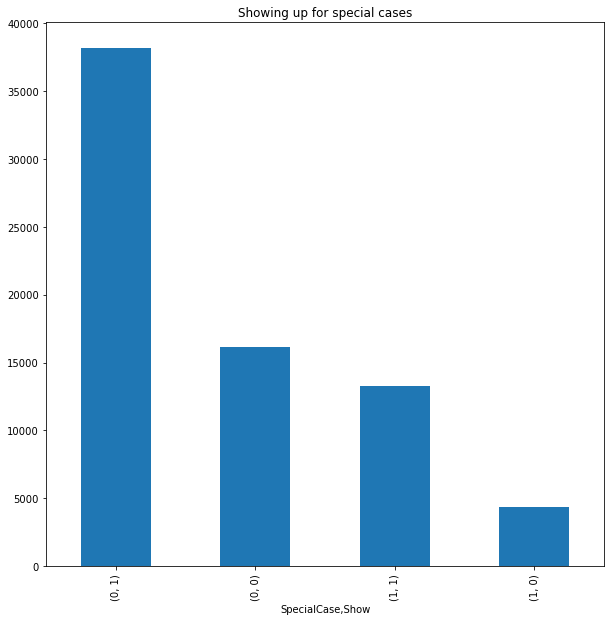

```python
counts=df_positive.groupby('SpecialCase')['Show'].value_counts()
barChart2('Showing up for special cases',counts,(10,10))
```

It seems that having a special case will not restarin patients from showing up for their appointments. Let's draw a pie chart to get a more precise picture.

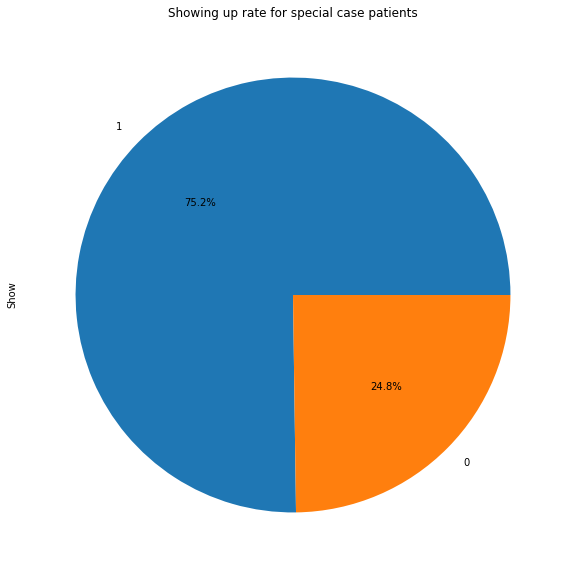

```python
counts= df_positive.query('SpecialCase==1')['Show'].value_counts()
pieChart2('Showing up rate for special case patients',counts,(10,10))
```

We can notice that the most of patient are not special cases and that most of special cases show up for their appointments. Let's analyze each special case symptom. Perhaps the persons who do not show up belongs to the same case. </br> As we know that having a special case in general is not impacting and we are checking the behaviour with each special case category, we will draw directly pie charts for patients presenting each case to check their rate of showing up.

##### Hipertension

[figure not shown]

```python
conts=df_positive.query('Hipertension==1')['Show'].value_counts()
pieChart2('Showing up for patients with hipertension',counts,(10,10))
```

##### Diabetes

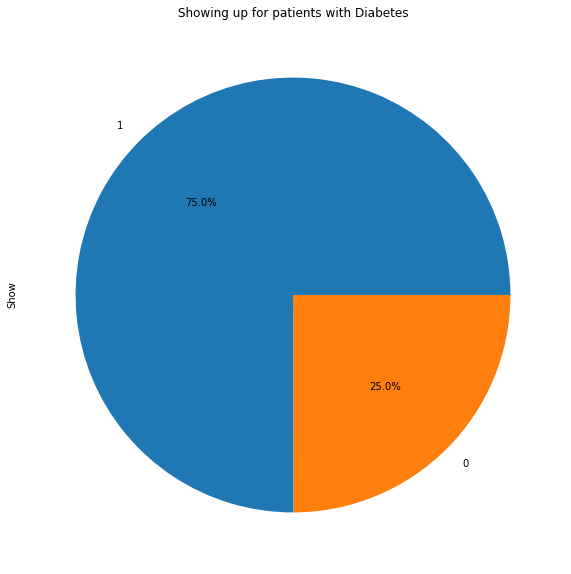

```python
counts=df_positive.query('Diabetes==1')['Show'].value_counts()
pieChart2('Showing up for patients with Diabetes',counts,(10,10))
```

##### Alcoholism

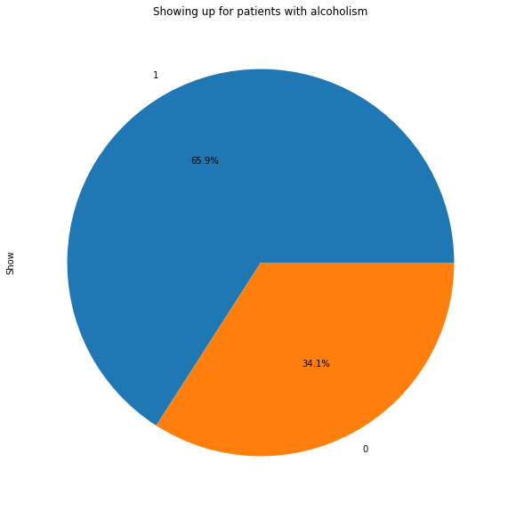

```python
counts=df_positive.query('Alcoholism==1')['Show'].value_counts()
pieChart2('Showing up for patients with alcoholism',counts,(10,10))
```

##### Handcap

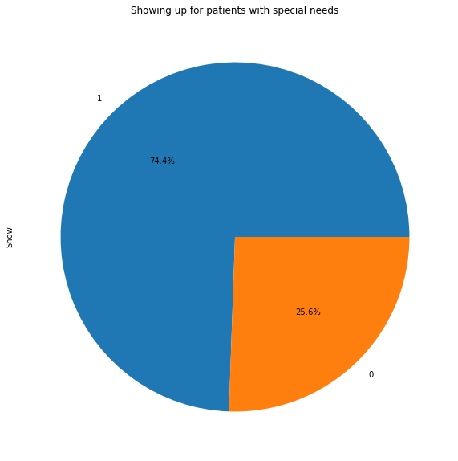

```python
counts=df_positive.query('Handcap!=0')['Show'].value_counts()
pieChart2('Showing up for patients with special needs',counts,(10,10))
```

We can conclude that being a special case does not retrain the patient from showing up. The highest rates of not showing up are for alchoholic and special needs patients.

### Research Question 10: Do some neighbourhood present a higher rate of people not showing up?

Let's draw some charts to check</br> First of all, let's draw a scatter plot to check if there are some neighbourhoods where patients do not show up at all or show up always

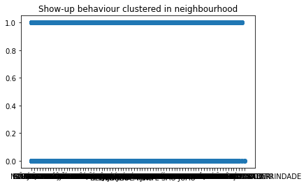

```python
plt.scatter('Neighbourhood','Show', data=df_positive)
plt.title('Show-up behaviour clustered in neighbourhood')
plt.show()
```

There is no special neighbourhood where patients have always showed up or have never showed up </br> Let's draw a bar chart to check the distribution of not showing up per neighbourhood.

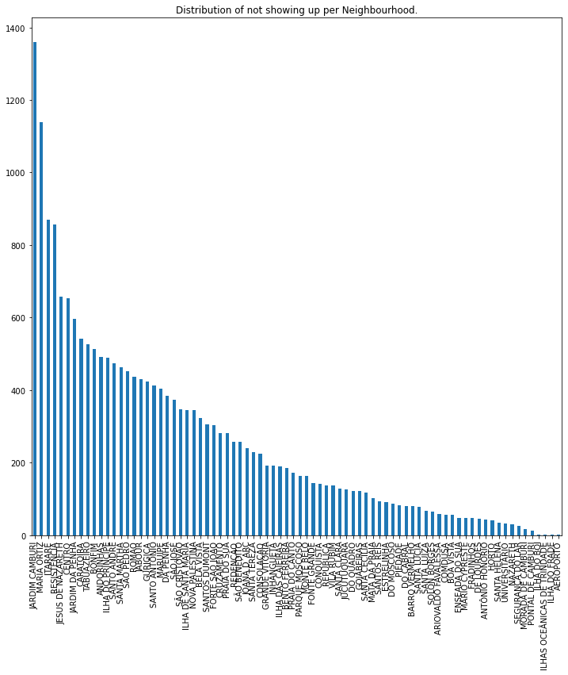

```python
counts=df_positive.query('Show==0')['Neighbourhood'].value_counts()
barChart2('Distribution of not showing up per Neighbourhood.',counts,(12,12))
```

Let's compare the result with the distribution of showing up per neighbourhood. For this, we will draw the same bar abover but for showing up entry.

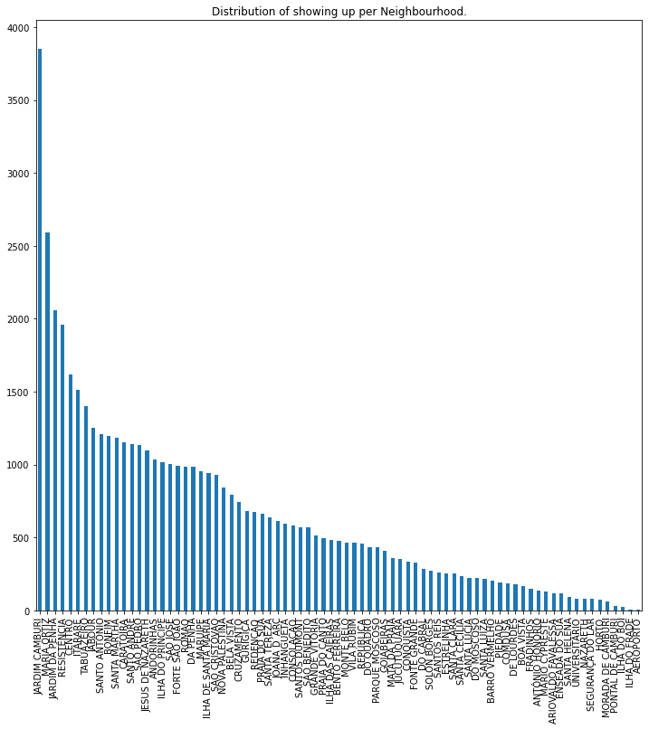

```python
counts=df_positive.query('Show==1')['Neighbourhood'].value_counts()
barChart2('Distribution of showing up per Neighbourhood.',counts,(12,12))
```

We can notice that the top neighbourhood in both bar charts are almost the same. Let's check the top 5 entries in Neighbourhood column to make sure that the bar chart is not following the percentage of entries in Neighbourhood.

```python
top5=np.array(df_positive['Neighbourhood'].value_counts().sort_values(ascending=False).head(5).index)
top5
```

```
array(['JARDIM CAMBURI', 'MARIA ORTIZ', 'RESISTÊNCIA', 'JARDIM DA PENHA',
       'ITARARÉ'], dtype=object)
```

We can notice that there are some neighbourhoods which are listed in above bar charts within top 5 but do not belong to top 5 entries. Hence we can conclude that patient do not show up depending on the neighbourhood.

## Conclusions

### Limitations:

- The data found in the dataset is corrupted. We found a negative age vaue and 34.9% of negative wait time entries which is considered a high rate especially that we needed to remove all these corrupted entries.
- The middleAge category (between 18 and 40) are the least to show up for an appointments. It could be a work related constraint. If we found occupation related entries in the dataset, we could make a more precise analysis
- The correlation between the dataset elements is very low. We cannot findout, using only correlation diagram and table, a direct relationship between No-Show and other entries